# bigscape_to_pheatmap

Clau Zirion

15/3/2022

# Make absence/presence heatmaps from BiG-SCAPE results

Before running this script you need to download the absence/presence table of every class from the `index.html` of the BiG-SCAPE results.

The working directory for this script must have: One absence_presence tsv for every BGC class, a metadata.csv downloaded from the original imputed metadata, abd file with a list of selected genomes to maintain in the reduced plot if it is needed

### Load the libraries

```r
library(pheatmap)
library(stringr)
library(tidyverse)
library(RColorBrewer)
```

## *Bacillus*

### Make the needed objects

Define a function to pivot the data frames:

```r
my_pivot_longer<-function(abs_pres_df){
  abs_pres_df_long<- abs_pres_df %>%
    pivot_longer(
      cols = starts_with('FAM'),
      names_to = "Familia",
      values_to = "Presencia"
    )
  return(abs_pres_df_long)
}
```

Make each absence presence table into an object. There is one for each BGC Class:

```r
setwd("/home/claudia/Documentos/genomas/zamia-dic2020/bigscape/bacillus/outdir_281221/absence_presence/")

nrps<-read.table("NRPS_absence_presence.tsv", header = TRUE,  sep="\t")
others<-read.table("others_absence_presence.tsv", header = TRUE,  sep="\t")
pksother<-read.table("pksother_absence_presence.tsv", header = TRUE,  sep="\t")
ripps<-read.table("RiPPs_absence_presence.tsv", header = TRUE,  sep="\t")
terpene<-read.table("terpene_absence_presence.tsv", header = TRUE,  sep="\t")
pnh<-read.table("PKSNRPHybrids_absence_presence.tsv", header = TRUE,  sep="\t")
```

Convert to long format:

```r
nrps<-my_pivot_longer(nrps)
others<-my_pivot_longer(others)
pksother<-my_pivot_longer(pksother)
ripps<-my_pivot_longer(ripps)
terpene<-my_pivot_longer(terpene)
pnh<-my_pivot_longer(pnh)
```

Bind data frames into one:

```r
listed_dfs<-list(nrps, others, pksother, ripps, terpene, pnh) # Make a list with all the data frames
names(listed_dfs)<-c("NRPS", "Otros", "PKS_Otros", "RiPPs", "Terpenos", "PKS_NRPS") # Give a name to each data frame in the list
complete_long<- bind_rows(listed_dfs, .id = "Clase") # Bind all the data frames of the list in a single object and create a column named Class that will have the name of the data frame source in each observation
```

Tidy up the complete_df

```r
complete_long<- relocate(complete_long, Clase, .before = Familia) # Reorder columns
complete_long$ACC <- str_replace(complete_long$ACC, pattern = " Bacteria.", replacement = "") # Eliminates the "Bacteria." from the genomes names using stringr library
complete_long$ACC <- str_replace(complete_long$ACC, pattern = "acillus", replacement = "") #Eliminates the #acillus" from the genomes names using stringr library (Only my genomes have it)
complete_long$ACC <- str_replace_all(complete_long$ACC, pattern = "_", replacement = " ") #Eliminates the #acillus" from the genomes names using stringr library (Only my genomes have it)
complete_long$Presencia <- str_replace_all(complete_long$Presencia, pattern = "2", replacement = "1")
complete_long$Presencia <- as.numeric(complete_long$Presencia)
```

Make another data frame only for the information of which Family corresponds to which Class:

```r
classes<-complete_long %>%
  select(Clase, Familia) %>% #Select only Class and Family columns
  unique()# Remove all the repeated rows
classes$Clase<-as.factor(classes$Clase) # Convert Class to factor
classes<-as.data.frame(classes) # Convert to data frame
rownames(classes)<-classes$Familia # Make the Family names to row names
classes<-select(classes, Clase) # Remove Family column
```

Convert to wide format:

```r
complete_long<-select(complete_long, ACC, Familia, Presencia) # Remove Class column from complete_long
complete_wide<- complete_long %>%
  pivot_wider(names_from = Familia, values_from = Presencia) # Convert to wide format
complete_wide[is.na(complete_wide)] <- 0 # Convert NAs to zeros
complete_df<-as.data.frame(complete_wide) # Convert from tibble to data frame
complete_df<-arrange(complete_df, ACC) # Arrange by alphabetical order in the ACC column
rownames(complete_df)<-complete_df$ACC # Rename rows
complete_df<-complete_df[,-1] # Remove column of names
```

Make metadata object (species_habitat):

```r
setwd("/home/claudia/Documentos/genomas/zamia-dic2020/bigscape/bacillus/outdir_281221/absence_presence/")

metadata<-read.csv("metadata.csv", header = TRUE, stringsAsFactors = TRUE) # Read the metadata table
species_habitat<-metadata %>%
  select(Species, Habitat) %>% # Make a smaller metadata only with names and habitats
  arrange(Species) # Make the table be ordered alphabetically
species_habitat[,1] = rownames(complete_df) # Change the species name in the table to the names in the complete_df so they have the exact same strings
rownames(species_habitat)<-species_habitat$Species
species_habitat<-select(species_habitat, Habitat)
species_habitat$Habitat<-factor(species_habitat$Habitat, levels = c("Plant", "Rhizosphere", "Animal", "Human", "Food", "Air", "Lake", "Marine", "Soil"))
#Translate species_habitat to Spanish
levels(species_habitat$Habitat)<-c("Planta", "Rhizosfera", "Animal", "Humano", "Comida", "Aire", "Lago", "Mar", "Suelo")
```

### Plot

Make color vectors

```r
ClassCols<- brewer.pal(length(levels(classes$Clase)),"PRGn")
names(ClassCols)<- levels(classes$Clase) # A color for each BGC Class
HabitatCols<- brewer.pal(length(levels(species_habitat$Habitat)), "BrBG")
names(HabitatCols)<-levels(species_habitat$Habitat) # A color for each Habitat
ListColour<- list (Clase = ClassCols,
                   Habitat = HabitatCols)
```

Make small vectors:

```r
mycolors<-c("lightgray", "brown") # make color vector for absence and presence
lg.brks<-c(0,1) # make vector to make the legends only show the two values
lb.brks<- c("Ausencia","Presencia") # make the labels of the legend say Absence and Presence instead of 0 and 1
```

Plot:

```r
setwd("/home/claudia/Documentos/genomas/zamia-dic2020/bigscape/bacillus/outdir_281221/absence_presence/")

pheatmap(complete_df,
         color= mycolors,
         border_color = "white",
         annotation_col = classes,
         annotation_row = species_habitat,
         annotation_colors = ListColour,
         legend_breaks = lg.brks,
         legend_labels = lb.brks,
         cutree_rows = 7,
         cutree_cols = 5,
         show_rownames = TRUE,
         legend=TRUE,
         height = 26,
         width = 22,
         main = "Presencia de familias de BGCs en genomas de Bacillus",
         filename = "completo_pheatmap.pdf")

complete_plot<- pheatmap(complete_df,
         color= mycolors,
         border_color = "white",
         annotation_col = classes,
         annotation_row = species_habitat,
         annotation_colors = ListColour,
         legend_breaks = lg.brks,
         legend_labels = lb.brks,
         cutree_rows = 4,
         cutree_cols = 5,
         show_rownames = TRUE,
         legend=FALSE,
         annotation_legend = TRUE,
         fontsize = 8,
         fontsize_col = 5,
         fontsize_row = 5,
         height = 26,
         width = 22)
```

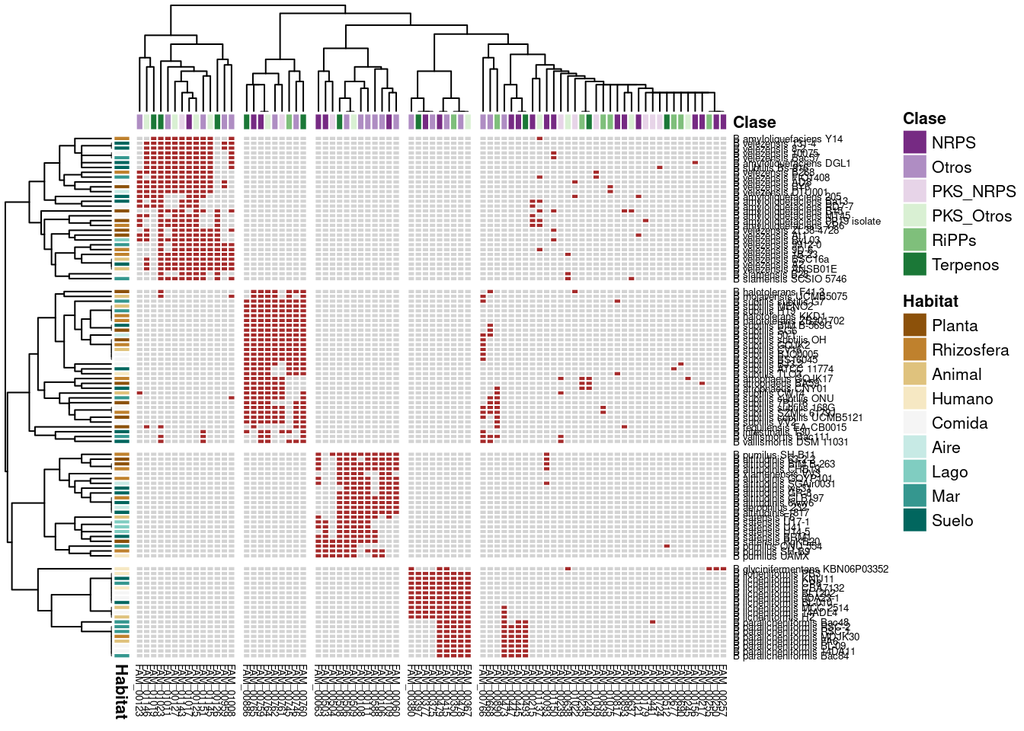

```r
complete_plot
```

## *Peribacillus*

### Make the needed objects

Make each absence presence table into an object. There is one for each BGC Class:

```r
setwd("/home/claudia/Documentos/genomas/zamia-dic2020/bigscape/peribacillus/outdir_241221/absence_presence/")

nrps<-read.table("NRPS_absence_presence.tsv", header = TRUE,  sep="\t")
others<-read.table("others_absence_presence.tsv", header = TRUE,  sep="\t")
pksother<-read.table("pksother_absence_presence.tsv", header = TRUE,  sep="\t")
ripps<-read.table("RiPPs_absence_presence.tsv", header = TRUE,  sep="\t")
terpene<-read.table("terpene_absence_presence.tsv", header = TRUE,  sep="\t")
```

Convert to long format:

```r
nrps<-my_pivot_longer(nrps)
others<-my_pivot_longer(others)
pksother<-my_pivot_longer(pksother)
ripps<-my_pivot_longer(ripps)
terpene<-my_pivot_longer(terpene)
```

Bind data frames into one:

```r
listed_dfs<-list(nrps, others, pksother, ripps, terpene) # Make a list with all the data frames
names(listed_dfs)<-c("NRPS", "Otros", "PKS_Otros", "RiPPs", "Terpenos") # Give a name to each data frame in the list
complete_long<- bind_rows(listed_dfs, .id = "Clase") # Bind all the data frames of the list in a single object and create a column named Class that will have the name of the data frame source in each observation
```

Tidy up the complete_df

```r
complete_long<- relocate(complete_long, Clase, .before = Familia) # Reorder columns
complete_long$ACC <- str_replace(complete_long$ACC, pattern = " Bacteria.", replacement = "") # Eliminates the "Bacteria." from the genomes names using stringr library
complete_long$ACC <- str_replace(complete_long$ACC, pattern = "eribacillus", replacement = "") #Eliminates the #acillus" from the genomes names using stringr library (Only my genomes have it)
complete_long$ACC <- str_replace_all(complete_long$ACC, pattern = "_", replacement = " ") #Eliminates the #acillus" from the genomes names using stringr library (Only my genomes have it)
```

Make another data frame only for the information of which Family corresponds to which Class:

```r
classes<-complete_long %>%
  select(Clase, Familia) %>% #Select only Class and Family columns
  unique()# Remove all the repeated rows
classes$Clase<-as.factor(classes$Clase) # Convert Class to factor
classes<-as.data.frame(classes) # Convert to data frame
rownames(classes)<-classes$Familia # Make the Family names to row names
classes<-select(classes, Clase) # Remove Family column
```

Convert to wide format:

```r
complete_long<-select(complete_long, ACC, Familia, Presencia) # Remove Class column from complete_long
complete_wide<- complete_long %>%
  pivot_wider(names_from = Familia, values_from = Presencia) # Convert to wide format
complete_wide[is.na(complete_wide)] <- 0 # Convert NAs to zeros
complete_df<-as.data.frame(complete_wide) # Convert from tibble to data frame
complete_df<-arrange(complete_df, ACC) # Arrange by alphabetical order in the ACC column
rownames(complete_df)<-complete_df$ACC # Rename rows
complete_df<-complete_df[,-1] # Remove column of names
```

Make metadata object (species_habitat):

```r
setwd("/home/claudia/Documentos/genomas/zamia-dic2020/bigscape/peribacillus/outdir_241221/absence_presence/")

metadata<-read.csv("metadata.csv", header = TRUE, stringsAsFactors = TRUE) # Read the metadata table
species_habitat<-metadata %>%
  select(Species, Habitat) %>% # Make a smaller metadata only with names and habitats
  arrange(Species) # Make the table be ordered alphabetically
species_habitat<- species_habitat %>%
  filter(Species != "B_subtilis_CW14")
species_habitat[,1] = rownames(complete_df) # Change the species name in the table to the names in the complete_df so they have the exact same strings
rownames(species_habitat)<-species_habitat$Species
species_habitat<-select(species_habitat, Habitat)
species_habitat$Habitat<-factor(species_habitat$Habitat, levels = c("Coralloid", "Root", "Rhizosphere","Soil"))
#Translate species_habitat to Spanish
levels(species_habitat$Habitat)<-c("Coraloide", "Raiz", "Rhizosfera","Suelo")

rownames(complete_df) <- str_replace(rownames(complete_df), pattern = " FDAARGOS-1161", replacement = "")
rownames(species_habitat) <- str_replace(rownames(species_habitat), pattern = " FDAARGOS-1161", replacement = "")
```

### Plot

Make color vectors

```r
ClassCols<- brewer.pal(length(levels(classes$Clase)),"PRGn")
names(ClassCols)<- levels(classes$Clase) # A color for each BGC Class
HabitatCols<- brewer.pal(length(levels(species_habitat$Habitat)), "BrBG")
names(HabitatCols)<-levels(species_habitat$Habitat) # A color for each Habitat
ListColour<- list (Clase = ClassCols,
                   Habitat = HabitatCols)
```

Make small vectors:

```r
mycolors<-c("lightgray", "darkgoldenrod") # make color vector for absence and presence
lg.brks<-c(0,1) # make vector to make the legends only show the two values
lb.brks<- c("Ausencia","Presencia") # make the labels of the legend say Absence and Presence instead of 0 and 1
```

Plot:

```r
pheatmap(complete_df,
         color= mycolors,
         border_color = "white",
         annotation_col = classes,
         annotation_row = species_habitat,
         annotation_colors = ListColour,
         legend_breaks = lg.brks,
         legend_labels = lb.brks,
         cutree_rows = 7,
         cutree_cols = 5,
         show_rownames = TRUE,
         legend=TRUE,
         height = 5,
         width = 10,
         main = "Presencia de familias de BGCs en genomas de Peribacillus",
         filename = "completo_pheatmap.pdf")

complete_plot<- pheatmap(complete_df,
         color= mycolors,
         border_color = "white",
         annotation_col = classes,
         annotation_row = species_habitat,
         annotation_colors = ListColour,
         legend_breaks = lg.brks,
         legend_labels = lb.brks,
         cutree_rows = 5,
         cutree_cols = 2,
         show_rownames = TRUE,
         legend=FALSE,
         annotation_legend = TRUE,
         height = 3,
         width = 6.5,
         fontsize = 8,
         fontsize_col = 8,
         fontsize_row = 8)
```

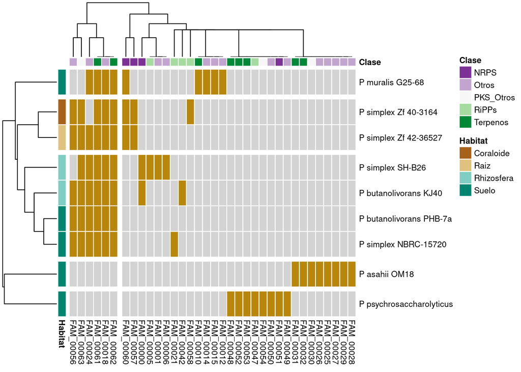

```r
complete_plot
```

## *Bradyrhizobium*

### Make the needed objects

Make each absence presence table into an object. There is one for each BGC Class:

```r
setwd("/home/claudia/Documentos/genomas/zamia-dic2020/bigscape/bradyrhizobium/output_05_07_21/absence-presence/")

nrps<-read.table("NRPS_absence_presence.tsv", header = TRUE,  sep="\t")
others<-read.table("others_absence_presence.tsv", header = TRUE,  sep="\t")
pksother<-read.table("pksother_absence_presence.tsv", header = TRUE,  sep="\t")
ripps<-read.table("RiPPs_absence_presence.tsv", header = TRUE,  sep="\t")
terpene<-read.table("terpene_absence_presence.tsv", header = TRUE,  sep="\t")
```

Convert to long format:

```r
nrps<-my_pivot_longer(nrps)
others<-my_pivot_longer(others)
pksother<-my_pivot_longer(pksother)
ripps<-my_pivot_longer(ripps)
terpene<-my_pivot_longer(terpene)
```

Bind data frames into one:

```r
listed_dfs<-list(nrps, others, pksother, ripps, terpene) # Make a list with all the data frames
names(listed_dfs)<-c("NRPS", "Otros", "PKS_Otros", "RiPPs", "Terpenos") # Give a name to each data frame in the list
complete_long<- bind_rows(listed_dfs, .id = "Clase") # Bind all the data frames of the list in a single object and create a column named Class that will have the name of the data frame Habitat in each observation
```

Tidy up the complete_df

```r
complete_long<- relocate(complete_long, Clase, .before = Familia) # Reorder columns
complete_long$ACC <- str_replace(complete_long$ACC, pattern = " Bacteria.", replacement = "") # Eliminates the "Bacteria." from the genomes names using stringr library
complete_long$ACC <- str_replace(complete_long$ACC, pattern = "radyrhizobium", replacement = "") #Eliminates the radyrhizobium" from the genomes names using stringr library (Only my genomes have it)
complete_long$ACC <- str_replace_all(complete_long$ACC, pattern = "_", replacement = " ") #Eliminates the #acillus" from the genomes names using stringr library (Only my genomes have it)
```

Make another data frame only for the information of which Family corresponds to which Class:

```r
classes<-complete_long %>%
  select(Clase, Familia) %>% #Select only Class and Family columns
  unique()# Remove all the repeated rows
classes$Clase<-as.factor(classes$Clase) # Convert Class to factor
classes<-as.data.frame(classes) # Convert to data frame
rownames(classes)<-classes$Familia # Make the Family names to row names
classes<-select(classes, Clase) # Remove Family column
```

Convert to wide format:

```r
complete_long<-select(complete_long, ACC, Familia, Presencia) # Remove Class column from complete_long
complete_wide<- complete_long %>%
  pivot_wider(names_from = Familia, values_from = Presencia) # Convert to wide format
complete_wide[is.na(complete_wide)] <- 0 # Convert NAs to zeros
complete_df<-as.data.frame(complete_wide) # Convert from tibble to data frame
complete_df<-arrange(complete_df, ACC) # Arrange by alphabetical order in the ACC column
```

Make metadata object (species_habitat):

```r
setwd("/home/claudia/Documentos/genomas/zamia-dic2020/bigscape/bradyrhizobium/output_05_07_21/absence-presence/")

metadata<-read.csv("metadata.csv", header = TRUE, stringsAsFactors = TRUE) # Read the metadata table
metadata$Species <- str_replace_all(metadata$Species, pattern = "_", replacement = " ")
metadata$Species <- str_replace_all(metadata$Species, pattern = "[.]", replacement = "")
species_habitat<-metadata %>%
  select(Species, Habitat) %>% # Make a smaller metadata only with names and habitats
  arrange(Species) # Make the table be ordered alphabetically
rownames(species_habitat)<-species_habitat$Species
species_habitat<-select(species_habitat, Habitat)
#Translate species_habitat to Spanish
species_habitat$Habitat<-factor(species_habitat$Habitat, levels = c ("Coralloid", "Root", "Root nodule", "Root tumor", "Stem nodule", "Insect gut", "Soil"))
levels(species_habitat$Habitat)<-c("Coraloide", "Raiz", "Nodulo de raiz", "Tumor de raiz", "Nodulo de tallo", "Intestino de insecto", "Suelo")
```

Tidy up the `complete_df`

```r
rownames(complete_df)<-rownames(species_habitat) #Make the rownames of the complete_df be identical to the rownames in the metadata
complete_df<-complete_df[,-1]
```

### Plot

Make color vectors

```r
ClassCols<- brewer.pal(length(levels(classes$Clase)),"PRGn")
names(ClassCols)<- levels(classes$Clase) # A color for each BGC Class
HabitatCols<- brewer.pal(length(levels(species_habitat$Habitat)), "BrBG")
names(HabitatCols)<-levels(species_habitat$Habitat) # A color for each Habitat
ListColour<- list (Clase = ClassCols,
                   Habitat = HabitatCols)
```

Make small vectors:

```r
mycolors<-c("lightgray", "#8E0152") # make color vector for absence and presence
lg.brks<-c(0,1) # make vector to make the legends only show the two values
lb.brks<- c("Ausencia","Presencia") # make the labels of the legend say Absence and Presence instead of 0 and 1
```

Plot:

```r
pheatmap(complete_df,
         color= mycolors,
         border_color = "white",
         annotation_col = classes,
         annotation_row = species_habitat,
         annotation_colors = ListColour,
         legend_breaks = lg.brks,
         legend_labels = lb.brks,
         cutree_rows = 3,
         cutree_cols = 4,
         show_rownames = TRUE,
         legend=TRUE,
         height = 11,
         width = 16,
         main = "Presencia de familias de BGCs en genomas de Bradyrhizobium",
         filename = "pheatmap_completo.pdf")

complete_plot<-pheatmap(complete_df,
         color= mycolors,
         border_color = "white",
         annotation_col = classes,
         annotation_row = species_habitat,
         annotation_colors = ListColour,
         legend_breaks = lg.brks,
         legend_labels = lb.brks,
         cutree_rows = 4,
         cutree_cols = 4,
         show_rownames = TRUE,
         legend=FALSE,
         height = 11,
         width = 16,
         fontsize = 8,
         fontsize_col = 5,
         fontsize_row = 6.5,
         annotation_legend = TRUE)
```

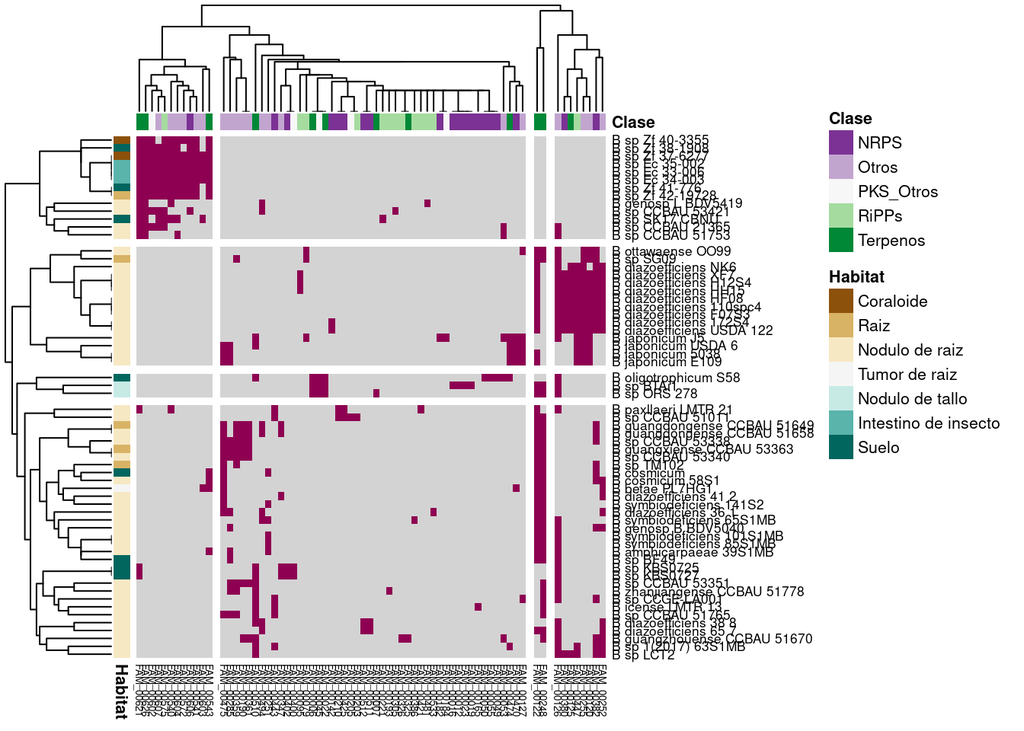

```r
complete_plot
```